# R Notebook

Notebook for Monocle trajectories of the 180504 dataset.

To investigate the robustness of the trajectories, the dataset was randomly downsampled on 1000 cells per sample. 4 different types of regressions were used when running the DDRTree algorithm.

```r
library(Seurat)
library(monocle)
```

Loading all datasets.

```r
cds.11 <- readRDS('../output/monocle/180504/10x-180504-monocle-11')
cds.cc.11 <- readRDS('../output/monocle/180504/10x-180504-monocle-cc-11')
cds.pm.umi.11 <- readRDS('../output/monocle/180504/10x-180504-monocle-pm-umi-11')
cds.pm.umi.cc.11 <- readRDS('../output/monocle/180504/10x-180504-monocle-pm-umi-cc-11')
cds.27 <- readRDS('../output/monocle/180504/10x-180504-monocle-27')
cds.cc.27 <- readRDS('../output/monocle/180504/10x-180504-monocle-cc-27')
```

# Trajectories of one subset

Trajectories of one subset, coloured by sample and cell cycle phase. Topleft: no regression. Topright: cell cycle regression. Bottom left: percent.mito + nUMI regression. Bottom right: percent.mito + nUMI + cell cycle regression.

[figure not shown]

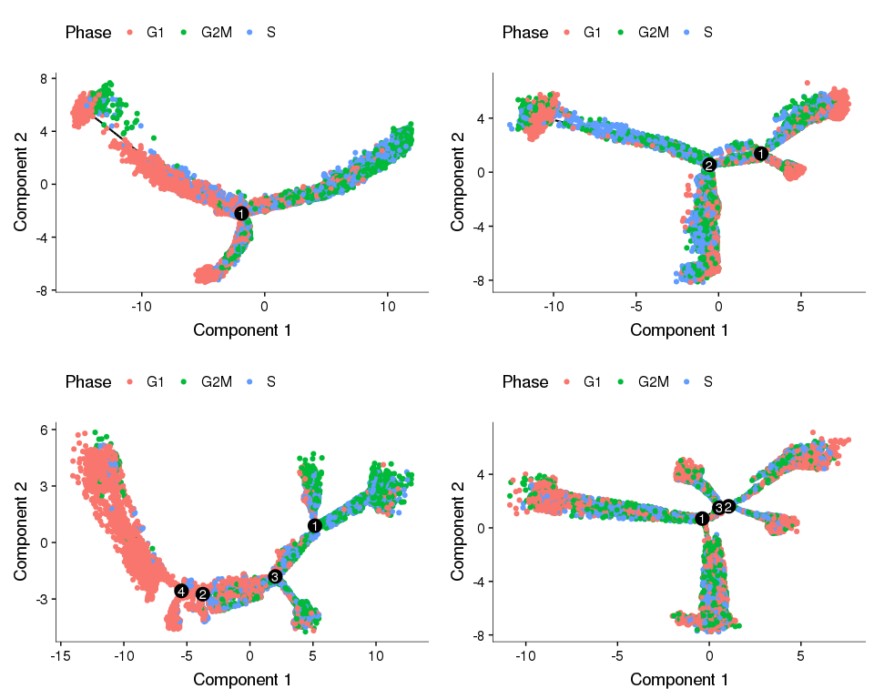

```r
plot_grid(
  plot_cell_trajectory(cds.11, color_by='Phase'),
  plot_cell_trajectory(cds.cc.11, color_by='Phase'),
  plot_cell_trajectory(cds.pm.umi.11, color_by='Phase'),
  plot_cell_trajectory(cds.pm.umi.cc.11, color_by='Phase'),
  nrow=2)
```

# Trajectories, no regression

Trajectories of the 4 subsets with no variables regressed out. The ordering of the cells seems to be influenced by the cell cycle state (though not completely). Interestingly in three of the trajectories there is a branch split.

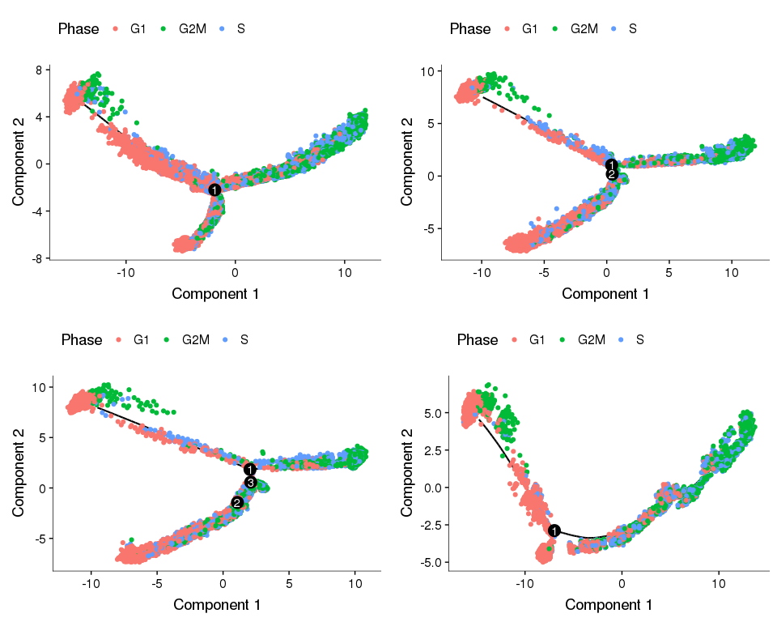

Does the branch split discriminate between depots?

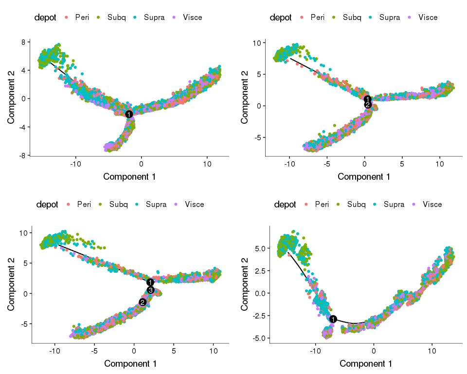

# Trajectories, cell cycle regression

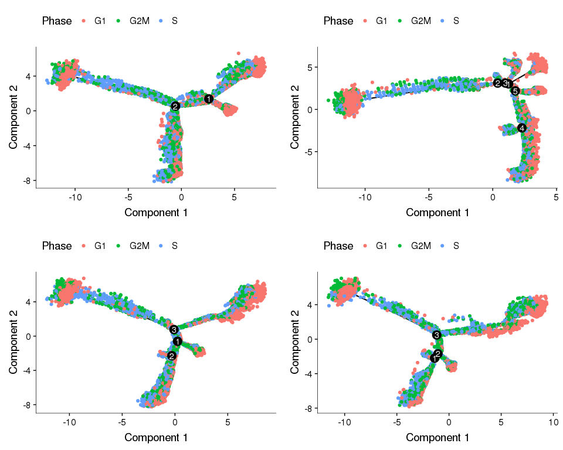

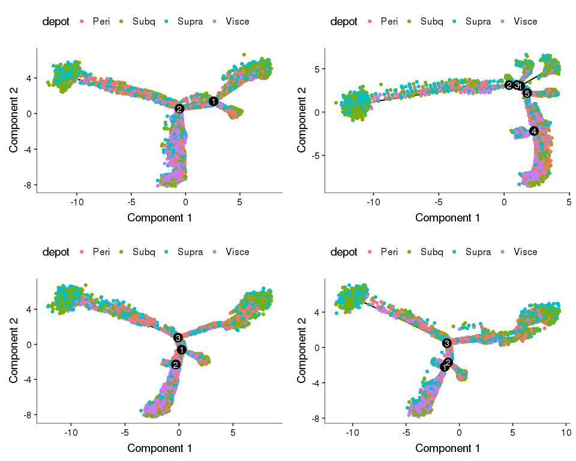

# Trajectories, percent.mito + nUMI regression

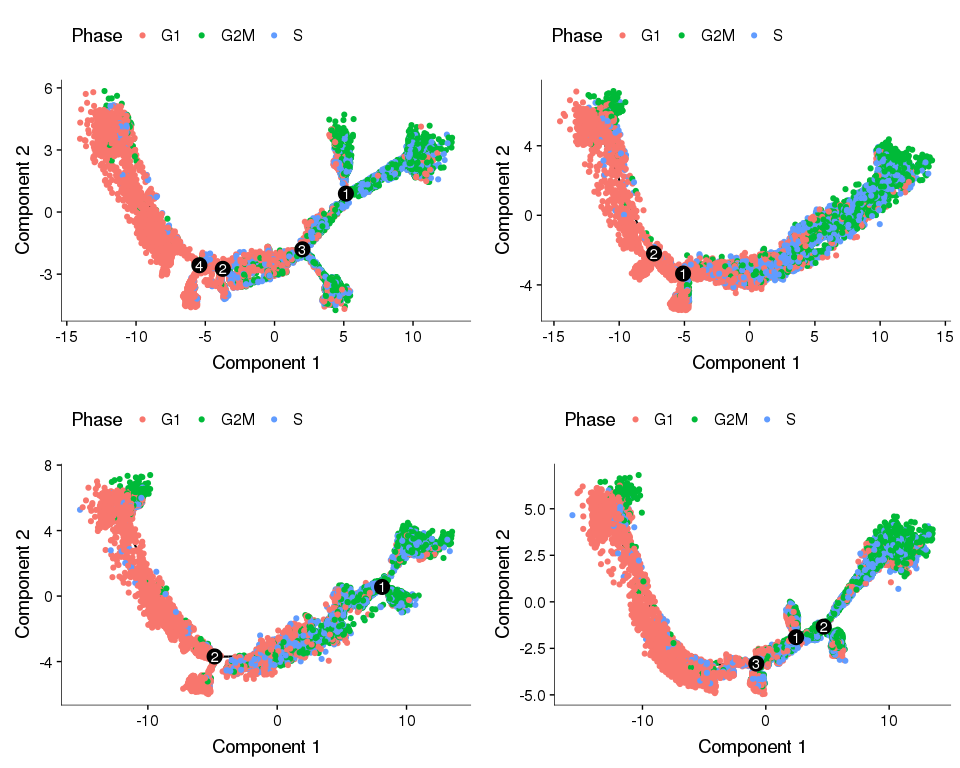

# Trajectories, percent.mito + nUMI + cell cycle regression

Trajectories with percent.mito, nUMI and cell cycle effects regressed out. Doesn’t look very convincing.

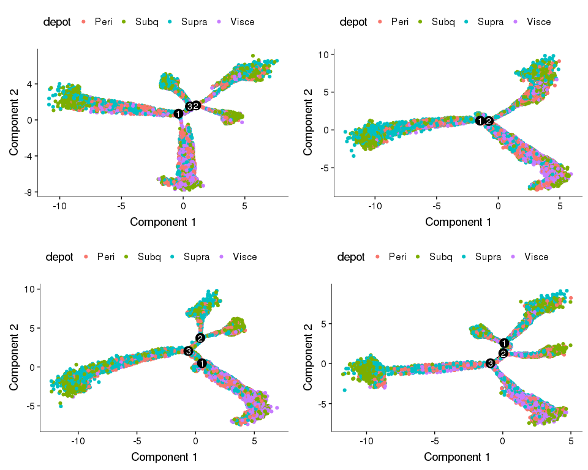

# Figures for report

a = trajectory without regressions, coloured on cell cycle phase. b = trajectory with cell cycle effects regressed out, coloured on depot.

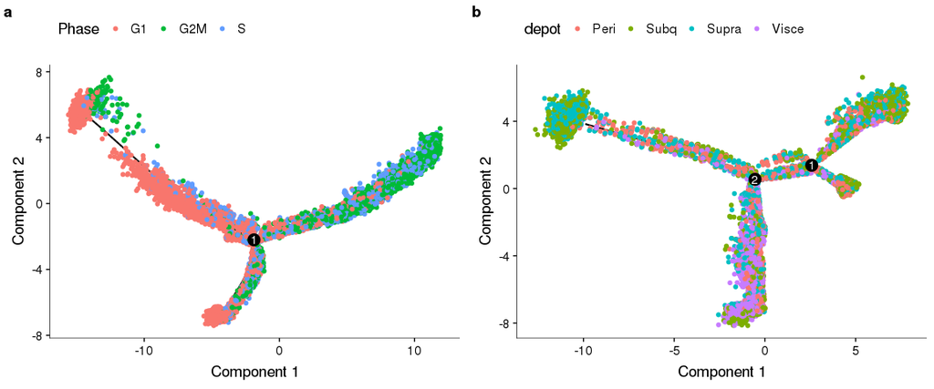

```r
fig <- plot_grid(
  plot_cell_trajectory(cds.11, color_by='Phase'),
  plot_cell_trajectory(cds.cc.11, color_by='depot'),
  nrow=1, labels='auto')
save_plot("../plots/180504_monocle_noreg-ccreg.pdf", fig, base_width=12, base_height=5)
fig
```

Supplementary figures

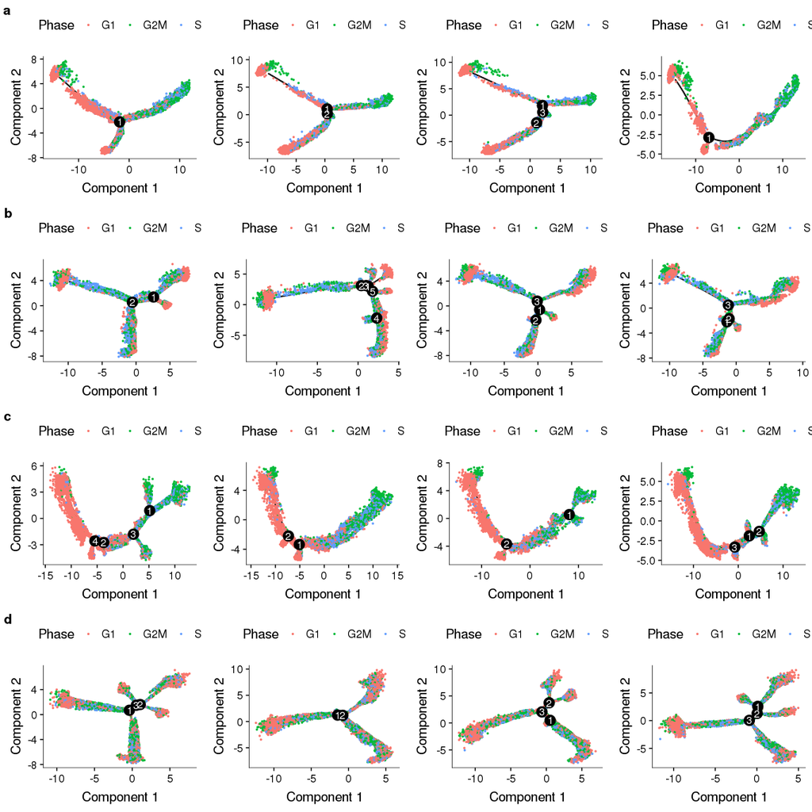

```r
noreg <- plot_grid(
  plot_cell_trajectory(cds.11, color_by='Phase', cell_size = 0.5),
  plot_cell_trajectory(cds.27, color_by='Phase', cell_size = 0.5),
  plot_cell_trajectory(cds.33, color_by='Phase', cell_size = 0.5),
  plot_cell_trajectory(cds.53, color_by='Phase', cell_size = 0.5),
  nrow=1)
ccreg <- plot_grid(
  plot_cell_trajectory(cds.cc.11, color_by='Phase', cell_size = 0.5),
  plot_cell_trajectory(cds.cc.27, color_by='Phase', cell_size = 0.5),
  plot_cell_trajectory(cds.cc.33, color_by='Phase', cell_size = 0.5),
  plot_cell_trajectory(cds.cc.53, color_by='Phase', cell_size = 0.5),
  nrow=1)
pmumireg <- plot_grid(
  plot_cell_trajectory(cds.pm.umi.11, color_by='Phase', cell_size = 0.5),
  plot_cell_trajectory(cds.pm.umi.27, color_by='Phase', cell_size = 0.5),
  plot_cell_trajectory(cds.pm.umi.33, color_by='Phase', cell_size = 0.5),
  plot_cell_trajectory(cds.pm.umi.53, color_by='Phase', cell_size = 0.5),
  nrow=1)
pmumiccreg <- plot_grid(
  plot_cell_trajectory(cds.pm.umi.cc.11, color_by='Phase', cell_size = 0.5),
  plot_cell_trajectory(cds.pm.umi.cc.27, color_by='Phase', cell_size = 0.5),
  plot_cell_trajectory(cds.pm.umi.cc.33, color_by='Phase', cell_size = 0.5),
  plot_cell_trajectory(cds.pm.umi.cc.53, color_by='Phase', cell_size = 0.5),
  nrow=1)
plot_grid(
  noreg,
  ccreg,
  pmumireg,
  pmumiccreg,
  labels='auto', nrow=4
)
```